# Hypothesis Testing ▶ Means or Proportions

Updated: Tuesday, November 05, 2019 @ 05:22:07 PM

## Before You Begin

Complete the following video lessons on AsULearn. They will introduce you to the logical framework of hypothesis testing, asymptotic tests for assessing the value of a single population mean or proportion using sample data, as well as comparing two population means or proportions.

- Theory and Concepts of Hypothesis Testing
- Classical Hypothesis Testing for One Mean
- Classical Hypothesis Testing for Two Means
- Classical Hypothesis Testing for Proportions

Also read the appropriate sections of *Chihara* Chapter 3. Class time will be used to supplement these materials, introduce the concepts and methods of permutation tests, and help develop connections between the mathematics and programming.

## Comments on Notation

Statistical notation can vary, since many disciplines have made contributions to statistical theory and practice. For means, we most often see the population mean represented by \(\mu\) and the sample mean represented by \(\bar{x}\). The textbook, the lesson videos, and these slides all follow this convention.

For proportions, one common notation is to use \(\pi\) to represent the population proportion with and \(p\) for the sample proportion (Greek versus Roman letters, like \(\mu\) and \(\bar{x}\)). These slides use that convention. However, the lesson videos use another common system where the population proportion is \(p\) and the sample is \(\widehat{p}\). The textbook seems to use a mix of notations.

In any context, make sure you know whether \(p\) is being used as the population parameter or sample statistic.

## Comparing Two Means

## Null and Alternative Hypotheses

The hypotheses for a test comparing means are written in terms of the population means \(\mu\).

null hypothesis

\[H_0: \mu_1 = \mu_2 \text{ or } H_0: \mu_1 - \mu_2 = 0\]

alternative hypothesis (two-tailed, lower-tailed, or upper-tailed)

\[H_a: \mu_1 \neq \mu_2 \text{ (or } H_a: \mu_1 - \mu_2 \neq 0)\]

\[H_a: \mu_1 < \mu_2 \text{ (or } H_a: \mu_1 - \mu_2 < 0)\]

\[H_a: \mu_1 > \mu_2 \text{ (or } H_a: \mu_1 - \mu_2 > 0)\]

## Traditional Test for Two Means

assumptions

- independent simple random samples from the populations
- normally distributed populations (or large enough samples)

test statistic (unpooled)

\[t=\frac{\bar{x}_1-\bar{x}_2}{\sqrt{\frac{s_1^2}{n_1}+\frac{s_2^2}{n_2}}}\]

The p-value is calculated using a *t* distribution with \(\nu\) degrees of freedom, where \(\nu\) depends on the sample sizes.

In R, we use `t.test()` to perform a test for two means.

## Comparing Two Means Example

Do brand name or generic batteries last longer? (batterylife.csv)

```r
str(battery)
```

```
'data.frame':   12 obs. of  2 variables:
 $ hours: num  174 181 184 194 199 ...
 $ type : Factor w/ 2 levels "Brand","Generic": 1 1 1 1 1 1 2 2 2 2 ...
```

```r
summaries <- battery %>%
  group_by(type) %>%
  summarize(n = n(), xbar = mean(hours), stdv = sd(hours))
print.data.frame(summaries, row.names = FALSE)
```

```
    type n     xbar     stdv
   Brand 6 189.6000 12.01782
 Generic 6 205.1833 10.73917
```

## Are there any outliers in the data?

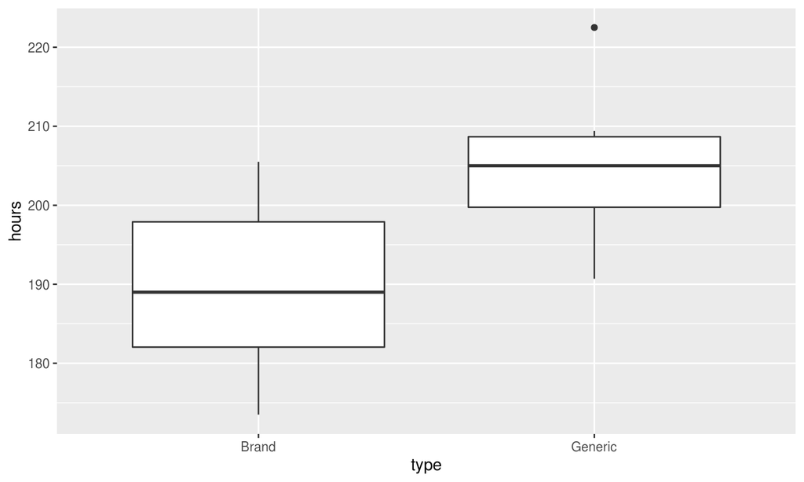

## Are the data normally distributed?

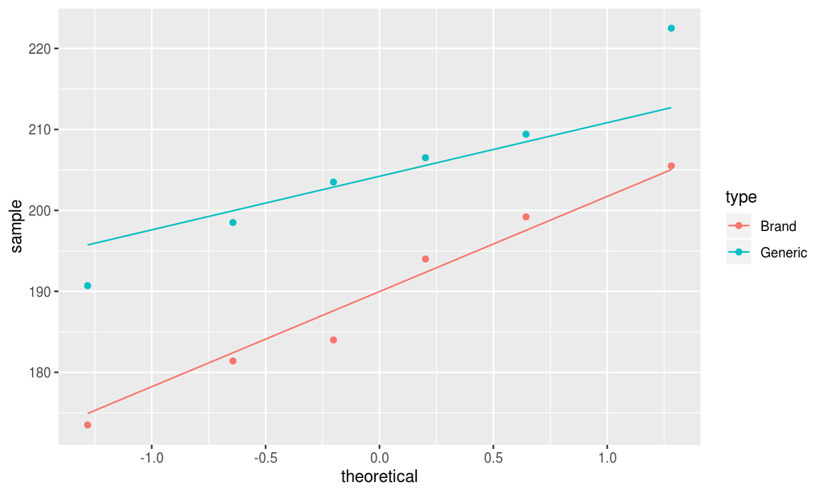

## The *t* Distribution

As degrees of freedom \(\nu \rightarrow \infty\), the \(t\) distribution converges to the standard normal distribution.

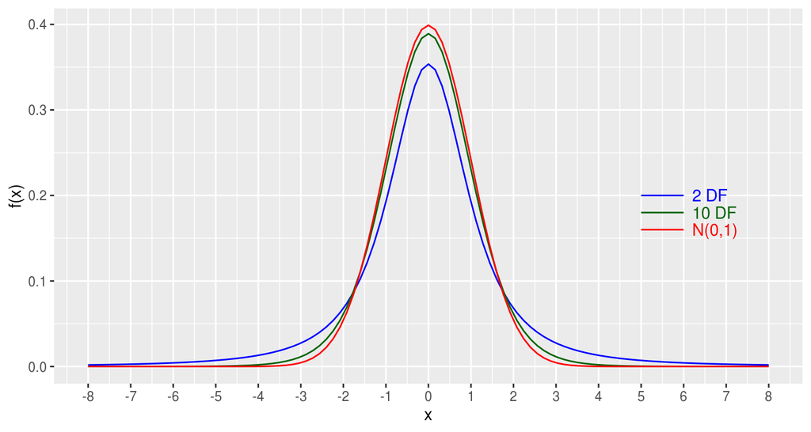

## Tests for Two Means

Open the R Markdown file [Testing Two Means](https://raw.githubusercontent.com/STAT-JET-ASU/StatisticalDataAnalysis1/master/TestingTwoMeans.Rmd) to continue. We will assess the hypotheses three different ways.

- traditional asymptotic t-test
- complete permutation test
- permutation resampling test

Pay attention to the assumptions of each test, the test statistic used, and the way in which the p-value is calculated.

## Comparing Proportions

## Null and Alternative Hypotheses

The hypotheses for a test comparing proportions are written in terms of the population proportions \(\pi\).

null hypothesis

\[H_0: \pi_1 = \pi_2 \text{ or } H_0: \pi_1 - \pi_2 = 0\]

alternative hypothesis (two-tailed, lower-tailed, or upper-tailed)

\[H_a: \pi_1 \neq \pi_2 \text{ (or } H_a: \pi_1 - \pi_2 \neq 0)\]

\[H_a: \pi_1 < \pi_2 \text{ (or } H_a: \pi_1 - \pi_2 < 0)\]

\[H_a: \pi_1 > \pi_2 \text{ (or } H_a: \pi_1 - \pi_2 > 0)\]

## Traditional Two-Proportion Test

assumptions

- independent simple random samples from the populations
- large enough sample sizes for the normal approximation to the binomial to be valid (one rule is np ≥ 15 and n(1-p) ≥ 15)

test statistic

\[z=\frac{p_1-p_2}{\sqrt{p(1-p)(\frac{1}{n_1}+\frac{1}{n_2})}}\]

The p-value is calculated using the standard normal distribution.

In R, we use `prop.test()` to conduct a test for two proportions.

## Comparing Proportions Example

Does a magnetic pulse affect navigation? (homingpigeons.csv)

```r
str(homing)
```

```
'data.frame':   77 obs. of  2 variables:
 $ group: Factor w/ 2 levels "control","magnet": 1 1 1 1 1 1 1 1 1 1 ...
 $ home : Factor w/ 2 levels "no","yes": 2 2 2 2 2 2 2 2 2 2 ...
```

```r
summaries <- homing %>%
  group_by(group) %>% summarize(n = n(),
                                p_hat_y = mean(home == "no"),
                                p_hat_n = mean(home == "yes"))
```

```
   group  n   p_hat_y   p_hat_n
 control 38 0.4210526 0.5789474
  magnet 39 0.4615385 0.5384615
```

## Visualize the Proportions

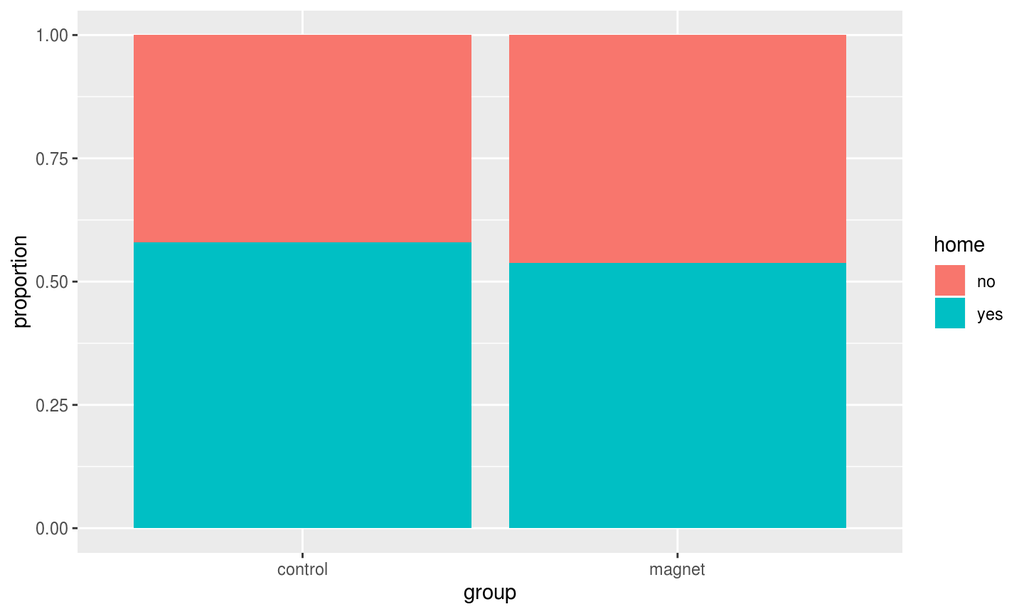

## Are np ≥ 15 and n(1−p) ≥ 15?

Recall the summaries we computed. We can use them to check the assumption by multiplying the appropriate vectors.

```
   group  n   p_hat_y   p_hat_n
 control 38 0.4210526 0.5789474
  magnet 39 0.4615385 0.5384615
```

```r
summaries$n * summaries$p_hat_y >= 15
```

```
[1] TRUE TRUE
```

```r
summaries$n * summaries$p_hat_n >= 15
```

```
[1] TRUE TRUE
```

## Tests for Two Proportions

- traditional test as implemented in R
  - the relationship between Z and \(\chi^2\) distributions
  - continuity correction for normal approximation
- permutation resampling test

Pay attention to the assumptions of each test, the test statistic used, and the way in which the p-value is calculated.

## Other Parameters

## Two Medians and Two Variances

- Let \(\theta_1\) and \(\theta_2\) be the medians of two populations, estimated by sample medians \(\widehat{\theta}_1\) and \(\widehat{\theta}_2\). Test whether the population medians are equal or not using permutation resampling.
- Let \(\sigma^2_1\) and \(\sigma^2_2\) be the variances of two populations, estimated by sample variances \(S^2_1\) and \(S^2_2\). Test whether the population variances are equal or not using permutation resampling.  
  The standard test statistic for two variances is the ratio \(\frac{S^2_1}{S^2_2}\).  
  Compare resampling results to the results of `var.test()`.

The F-test for variances assumes that we have two independent random samples from normally distributed populations.